# R Notebook

AGE GROUP

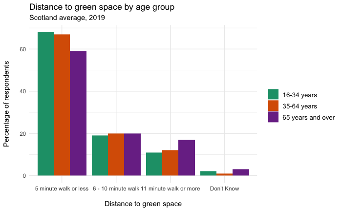

Oldest age group has worst access to green space. Under 60% are within a five minute walk, while 17% are 11 minutes or more.

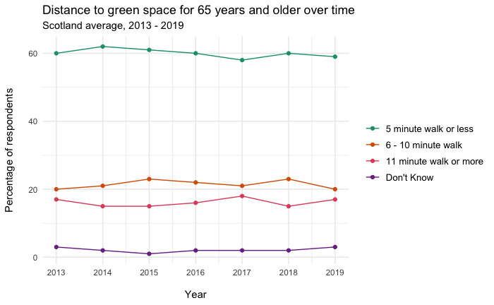

And the percentage within five minutes is trending slightly downward over time.

URBAN RURAL CLASSIFICATION

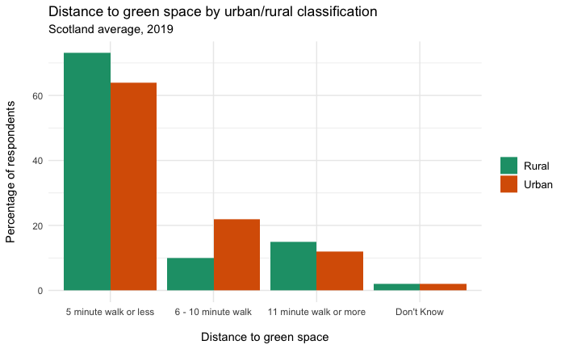

Mixed results for urban/rural. There are more people living in rural areas who are 11+ minutes from green space than there are 6-10 minutes.

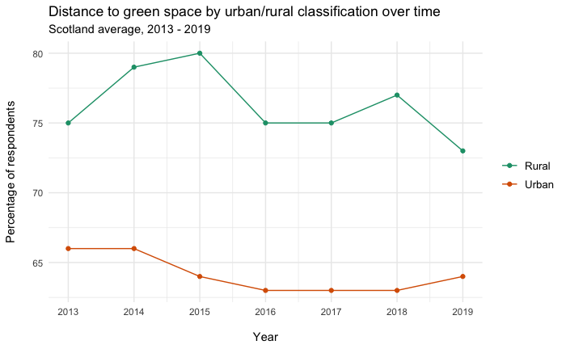

SIMD QUINTILES

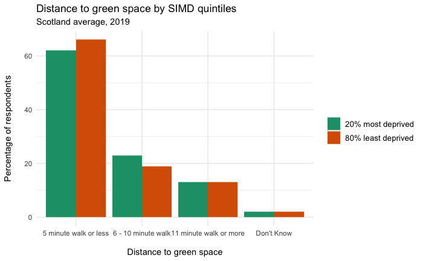

Marked difference between 20% most deprived and 80% least within five minute walk.

However, those in the 80% least deprived areas within a five minute walk showing a clear downward trend over time.

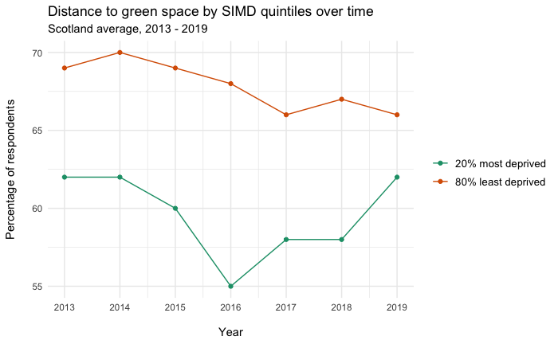

TYPE OF TENURE

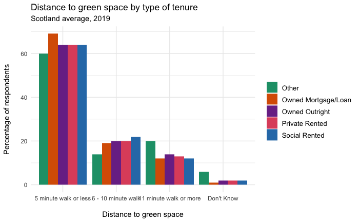

No significant differences between type of tenure, though those that own their home with a mortgage or loan have the best access to green space within five minutes.

HOUSEHOLD TYPE

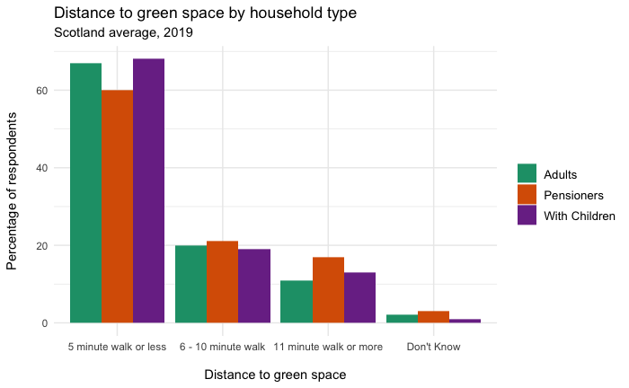

Pensioners have least access to green space within five minutes, while 17% are more than 11 minutes away.

| feature_code | date_code | measurement | value | distance_to_green_space | age | gender | urban_rural_classification | simd_quintiles | type_of_tenure | household_type | ethnicity | name |
| --- | --- | --- | --- | --- | --- | --- | --- | --- | --- | --- | --- | --- |
| S92000003 | 2019 | Percent | 3 | Don't Know | All | All | All | All | All | Pensioners | All | Scotland |
| S92000003 | 2019 | Percent | 60 | 5 minute walk or less | All | All | All | All | All | Pensioners | All | Scotland |
| S92000003 | 2019 | Percent | 17 | 11 minute walk or more | All | All | All | All | All | Pensioners | All | Scotland |
| S92000003 | 2019 | Percent | 21 | 6 - 10 minute walk | All | All | All | All | All | Pensioners | All | Scotland |

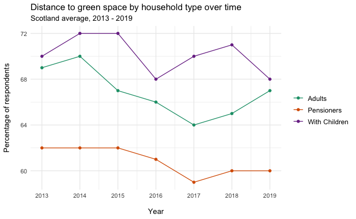

ETHNICITY

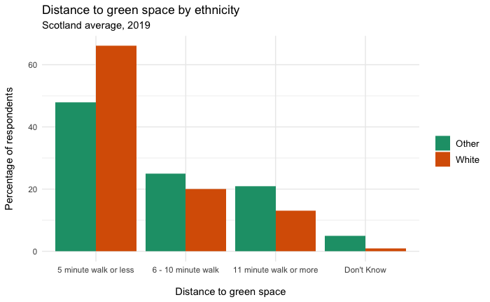

Very significant difference between those identifying as “White” and those who don’t.

Non-whites make up 8% of the sample size in 2019 (latest census in 2011 reported that non-whites make up 4% of the population of Scotland).

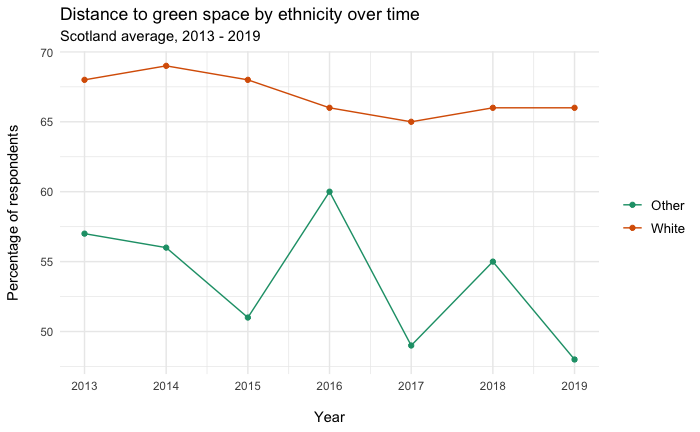

Data points for non-white respondents much more erratic due to the smaller proportion. However, chart shows there is a clear downward trend of these respondents saying they are within five minutes walk of green space - dropping from 57% in 2013 to 48% in 2019.

| feature_code | date_code | measurement | value | distance_to_green_space | age | gender | urban_rural_classification | simd_quintiles | type_of_tenure | household_type | ethnicity | name |
| --- | --- | --- | --- | --- | --- | --- | --- | --- | --- | --- | --- | --- |
| S92000003 | 2013 | Percent | 57 | 5 minute walk or less | All | All | All | All | All | All | Other | Scotland |
| S92000003 | 2019 | Percent | 48 | 5 minute walk or less | All | All | All | All | All | All | Other | Scotland |

COMMUNITY ~ HOUSEHOLD TYPE

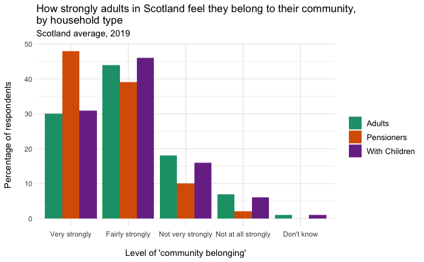

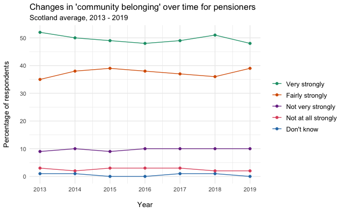

Slight decrease over time among pensioners who feel very strongly about community belonging.

However, more than 80% of pensioners still consider themselves either very or fairly strongly a part of their community.

COMMUNITY ~ ETHNICITY

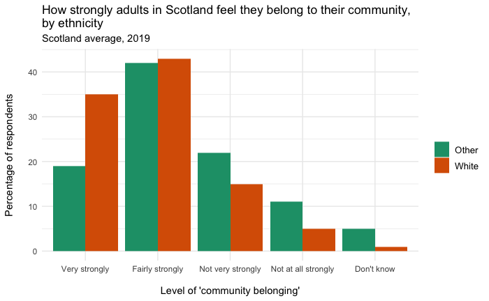

Only 19% of non-white people stated they felt very strongly that they belong to their immediate neighbourhood (down from 23% in 2013), compared to 35% of white people.

Only 61% of non-white people felt very or fairly strongly, compared to 78% of white people.

11% of non-white people felt not at all strongly that they belong to their immediate neighbourhood.

| feature_code | date_code | measurement | value | community_belonging | gender | urban_rural_classification | simd_quintiles | type_of_tenure | household_type | ethnicity | walking_distance_to_nearest_greenspace | name |
| --- | --- | --- | --- | --- | --- | --- | --- | --- | --- | --- | --- | --- |
| S92000003 | 2013 | Percent | 3 | Don't know | All | All | All | All | All | Other | All | Scotland |
| S92000003 | 2013 | Percent | 24 | Not very strongly | All | All | All | All | All | Other | All | Scotland |
| S92000003 | 2013 | Percent | 41 | Fairly strongly | All | All | All | All | All | Other | All | Scotland |
| S92000003 | 2013 | Percent | 23 | Very strongly | All | All | All | All | All | Other | All | Scotland |
| S92000003 | 2013 | Percent | 9 | Not at all strongly | All | All | All | All | All | Other | All | Scotland |

NEIGHBOURHOOD ~ HOUSEHOLD TYPE

[figure not shown]

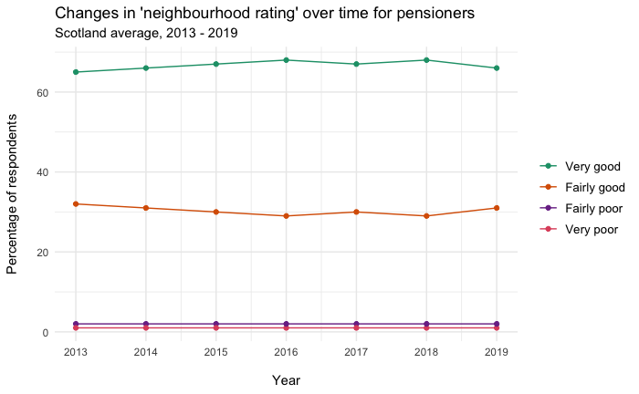

NEIGHBOURHOOD ~ ETHNICITY

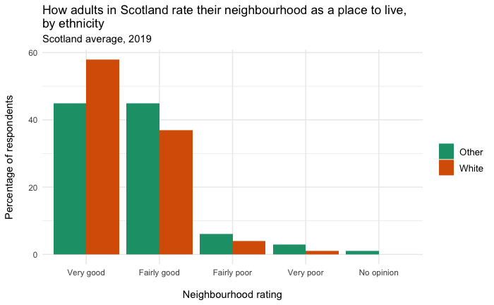

| feature_code | date_code | measurement | value | neighbourhood_rating | gender | urban_rural_classification | simd_quintiles | type_of_tenure | household_type | ethnicity | walking_distance_to_nearest_greenspace | name |
| --- | --- | --- | --- | --- | --- | --- | --- | --- | --- | --- | --- | --- |
| S92000003 | 2019 | Percent | 1 | No opinion | All | All | All | All | All | Other | All | Scotland |
| S92000003 | 2019 | Percent | 45 | Very good | All | All | All | All | All | Other | All | Scotland |
| S92000003 | 2019 | Percent | 3 | Very poor | All | All | All | All | All | Other | All | Scotland |
| S92000003 | 2019 | Percent | 45 | Fairly good | All | All | All | All | All | Other | All | Scotland |
| S92000003 | 2019 | Percent | 6 | Fairly poor | All | All | All | All | All | Other | All | Scotland |
| S92000003 | 2019 | Percent | 1 | Very poor | All | All | All | All | All | White | All | Scotland |
| S92000003 | 2019 | Percent | 0 | No opinion | All | All | All | All | All | White | All | Scotland |
| S92000003 | 2019 | Percent | 58 | Very good | All | All | All | All | All | White | All | Scotland |
| S92000003 | 2019 | Percent | 37 | Fairly good | All | All | All | All | All | White | All | Scotland |
| S92000003 | 2019 | Percent | 4 | Fairly poor | All | All | All | All | All | White | All | Scotland |

Nearly twice as many non-white people rated their neighbourhood as either very or fairly poor compared to white people.

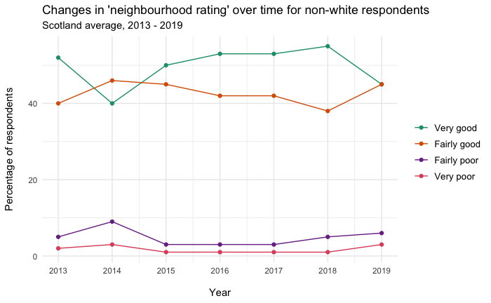

Not much in the way of a trend but fewer non-white people rated their neighbourhood as very good in 2019 than in 2013.